# Data Analytics Project

# Predicting Hypertension

## Introduction

Hypertension is a condition where the pressure in a person’s arteries is consistently abnormally high, which can lead to many fatal risks such as stroke, kidney diseases, and other cardiovascular diseases (Baliga and Bakris, 1). Studies have shown that “unhealthy levels” (Baliga and Bakris, 29) of sodium and above-average glucose concentrations are common among hypertensive men.

The dataset used in this project is from UC Irvine’s Machine Learning Repository and contains 25 different variables. It has been collected from a hospital within a two month period, and is designed for predicting chronic kidney disease. In this project, we wanted to determine whether leading factors of hypertensions explored by several medical research articles are also leading factors for hypertension in our data set taken from the UC Irvine’s Machine Learning repository collected for Chronic Kidney Disease. That is, we wanted to examine if the factors: sodium, blood pressure, and age are good predictors for hypertension. We define good as predictors with an accuracy of above 85% in their respective classifiers, and classifiers without these predictors do not fluctuate more than 5% in accuracy

```r
library(repr)
library(tidyverse)
library(testthat)
library(digest)
library(caret)
library(GGally)
```

## Methods

To obtain the dataset, we downloaded the chronic_kidney_disease_full.csv file through github and uploaded the csv file into the Jupyter notebook. Since the data was a comma separated separated csv file, the dataset is tidy; each row is a single observation, each variable is a single column, and each value is a single cell. Thus, minimal wrangling was needed.

```r
hypertension_data <- read_csv(file.choose())
head(hypertension_data)
```

```
## # A tibble: 6 x 25
##     age    bp    sg    al    su rbc    pc    pcc   ba      bgr    bu    sc   sod
##   <dbl> <dbl> <dbl> <dbl> <dbl> <chr>  <chr> <chr> <chr> <dbl> <dbl> <dbl> <dbl>
## 1    48    80  1.02     1     0 <NA>   norm~ notp~ notp~   121    36   1.2    NA
## 2     7    50  1.02     4     0 <NA>   norm~ notp~ notp~    NA    18   0.8    NA
## 3    62    80  1.01     2     3 normal norm~ notp~ notp~   423    53   1.8    NA
## 4    48    70  1.00     4     0 normal abno~ pres~ notp~   117    56   3.8   111
## 5    51    80  1.01     2     0 normal norm~ notp~ notp~   106    26   1.4    NA
## 6    60    90  1.01     3     0 <NA>   <NA>  notp~ notp~    74    25   1.1   142
## # ... with 12 more variables: pot <dbl>, hemo <dbl>, pcv <dbl>, wbcc <dbl>,
## #   rbcc <dbl>, htn <chr>, dm <chr>, cad <chr>, appet <chr>, pe <chr>,
## #   ane <chr>, class <chr>
```

We removed any NA values we found for our selected columns when building our classifier. Also, some variables had significantly lower values than others, so we scaled them.

```r
nrow(hypertension_data) # Number of rows before removing NA values
```

```
## [1] 400
```

```r
dataset_hyper <- hypertension_data %>% select(age,bp,sod, htn)
new_dataset_hyper <- dataset_hyper %>%
    na.omit()
scaled_hyper <- new_dataset_hyper %>%
  select(-c(htn)) %>%
  scale(center = FALSE) %>% data.frame()
htn_column <- new_dataset_hyper %>%
        select(htn) %>% data.frame()
new_scaled_hyper <- cbind(scaled_hyper, htn_column)
head(new_scaled_hyper)
```

```
##         age        bp       sod htn
## 1 0.8809780 0.9036961 0.8037012 yes
## 2 1.1012225 1.1618950 1.0281583 yes
## 3 1.2480521 0.9036961 0.7530173  no
## 4 0.9727465 1.1618950 0.8254229 yes
## 5 1.1562836 0.9036961 0.9485122 yes
## 6 1.2480521 0.9036961 0.9991961 yes
```

```r
nrow(new_scaled_hyper) # Number of rows after removing NA values
```

```
## [1] 297
```

Furthermore, to visualize the variables, we used a ggpairs plot to represent the distribution of data points, especially in relation with whether or not the given patient had hypertension. This helped us visually identify which variables caused distinct groupings between hypertensive and non-hypertensive subjects. The function ggpairs() was helpful to visualize the relationships between all the variables within each respective individual classifiers.

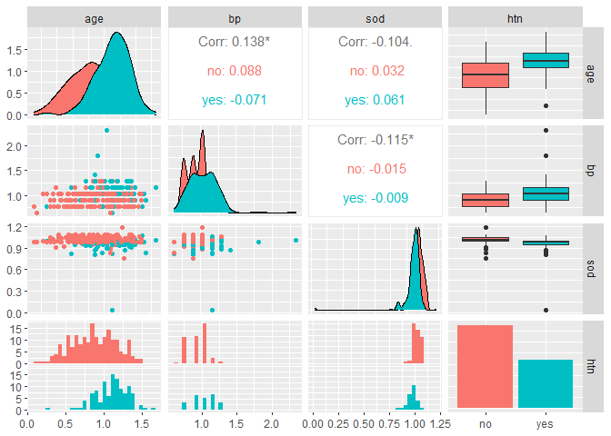

```r
options(repr.plot.width = 6, repr.plot.height = 5)

plotting <- new_scaled_hyper %>% ggpairs(aes(color = htn))
plotting
```

### KNN Analysis

```r
set.seed(1234)
training_rows <- new_scaled_hyper %>%
  select(htn) %>%
  unlist() %>% # converts Class from a tibble to a vector
  createDataPartition(p = 0.75, list = FALSE)
```

```r
# Generating the training and testing sets
training_set <- new_scaled_hyper  %>% slice(training_rows)
testing_set <- new_scaled_hyper  %>% slice(-training_rows)
X_train <- training_set %>%
  select(-htn) %>%
  data.frame()
Y_train <- training_set %>%
  select(htn) %>%
  unlist()
```

```r
ks <- data.frame(k = seq(from = 1, to = 30, by = 2))
train_control <- trainControl(method = "cv", number = 10)
choose_k <- train(x = X_train, y = Y_train,  method = "knn", tuneGrid = ks, trControl = train_control)
choose_k
```

```
## k-Nearest Neighbors
##
## 223 samples
##   3 predictor
##   2 classes: 'no', 'yes'
##
## No pre-processing
## Resampling: Cross-Validated (10 fold)
## Summary of sample sizes: 201, 201, 201, 201, 201, 200, ...
## Resampling results across tuning parameters:
##
##   k   Accuracy   Kappa
##    1  0.7000000  0.3551896
##    3  0.7448617  0.4561754
##    5  0.7804348  0.5281419
##    7  0.7626482  0.4888208
##    9  0.7717391  0.5078805
##   11  0.7986166  0.5696175
##   13  0.8031621  0.5775468
##   15  0.8077075  0.5891896
##   17  0.8077075  0.5881909
##   19  0.7760870  0.5224942
##   21  0.7760870  0.5249829
##   23  0.7982213  0.5720205
##   25  0.7893281  0.5522714
##   27  0.7934783  0.5601896
##   29  0.8071146  0.5908515
##
## Accuracy was used to select the optimal model using the largest value.
## The final value used for the model was k = 17.
```

```r
options(repr.plot.width = 4, repr.plot.height = 2.5)
k_accuracies <- choose_k$results
k_accuracies
```

```
##     k  Accuracy     Kappa AccuracySD   KappaSD
## 1   1 0.7000000 0.3551896 0.08132864 0.1727317
## 2   3 0.7448617 0.4561754 0.11119399 0.2323673
## 3   5 0.7804348 0.5281419 0.07651537 0.1582262
## 4   7 0.7626482 0.4888208 0.09085394 0.1890830
## 5   9 0.7717391 0.5078805 0.10325654 0.2144898
## 6  11 0.7986166 0.5696175 0.09783640 0.1926916
## 7  13 0.8031621 0.5775468 0.09022003 0.1774758
## 8  15 0.8077075 0.5891896 0.10607922 0.2115137
## 9  17 0.8077075 0.5881909 0.10607922 0.2103569
## 10 19 0.7760870 0.5224942 0.09549566 0.1909802
## 11 21 0.7760870 0.5249829 0.11409343 0.2169438
## 12 23 0.7982213 0.5720205 0.09437296 0.1871881
## 13 25 0.7893281 0.5522714 0.09656285 0.1952847
## 14 27 0.7934783 0.5601896 0.10351678 0.2121290
## 15 29 0.8071146 0.5908515 0.11036645 0.2292299
```

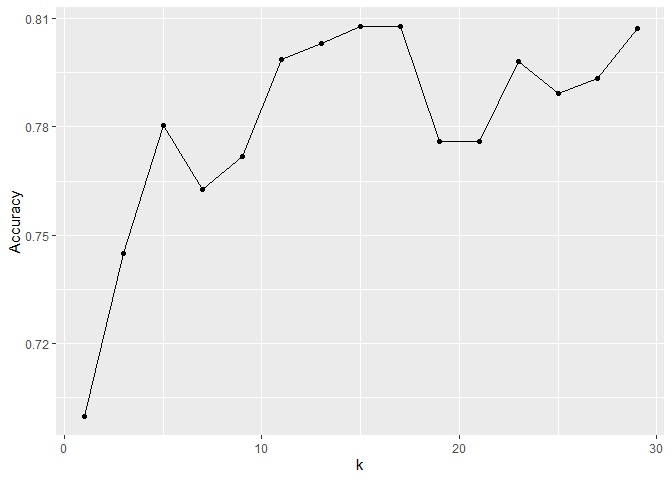

```r
choose_k_plot <- ggplot(k_accuracies, aes(x = k, y = Accuracy)) +
    geom_line() +
    geom_point()
choose_k_plot
```

## Model

We built four different models, each using three different variables to predict whether a person has hypertension or not. The first classifier is the control, where the predictors age, blood pressure, and sodium levels are used.The other three models are each run using three randomly selected predictors. To randomize variables, we took all the existing numerical variables in the data set, and randomized them using an online list randomizer from random.org. By comparing these classifiers, we can assess our hypothesis.

### Classifier 1

Also, for reproducibility we set the seed to 1234 each time we trained our model.

```r
k = data.frame(k=27)
final_model <- train(x = X_train, y = Y_train, method = "knn", tuneGrid = k)

X_test <- testing_set %>%
    select(-htn) %>%
    data.frame()
Y_test <- testing_set %>%
    select(htn) %>%
    unlist()

test_pred <- predict(final_model, X_test)
test_results <- confusionMatrix(table(test_pred, Y_test))
test_results
```

```
## Confusion Matrix and Statistics
##
##          Y_test
## test_pred no yes
##       no  38  10
##       yes  9  17
##
##                Accuracy : 0.7432
##                  95% CI : (0.6284, 0.8378)
##     No Information Rate : 0.6351
##     P-Value [Acc > NIR] : 0.03267
##
##                   Kappa : 0.4416
##
##  Mcnemar's Test P-Value : 1.00000
##
##             Sensitivity : 0.8085
##             Specificity : 0.6296
##          Pos Pred Value : 0.7917
##          Neg Pred Value : 0.6538
##              Prevalence : 0.6351
##          Detection Rate : 0.5135
##    Detection Prevalence : 0.6486
##       Balanced Accuracy : 0.7191
##
##        'Positive' Class : no
##
```

### Classifier 2

Then, we randomly chose three other variables (Hemoglobin, White Blood Cell Count, Blood Glucose Random) and used a similar procedure for our second classifier.

```r
dataset_hyper2 <- hypertension_data %>% select(hemo,wbcc,bgr, htn)
new_dataset_hyper2 <- dataset_hyper2 %>%
    na.omit()
scaled_hyper2 <- new_dataset_hyper2 %>%
  select(-c(htn)) %>%
  scale(center = FALSE) %>% data.frame()
htn_column <- new_dataset_hyper2 %>%
        select(htn) %>% data.frame()
new_scaled_hyper2 <- cbind(scaled_hyper2, htn_column)
head(new_scaled_hyper2)
```

```
##        hemo      wbcc       bgr htn
## 1 1.1575955 0.8724086 0.7381273 yes
## 2 0.7216180 0.8388544 2.5803955  no
## 3 0.8418876 0.7493766 0.7137264 yes
## 4 0.8719551 0.8164850 0.6466239  no
## 5 0.9170562 0.8724086 0.4514167 yes
## 6 0.9320899 0.7717461 2.5010925  no
```

```r
nrow(new_scaled_hyper2)
```

```
## [1] 261
```

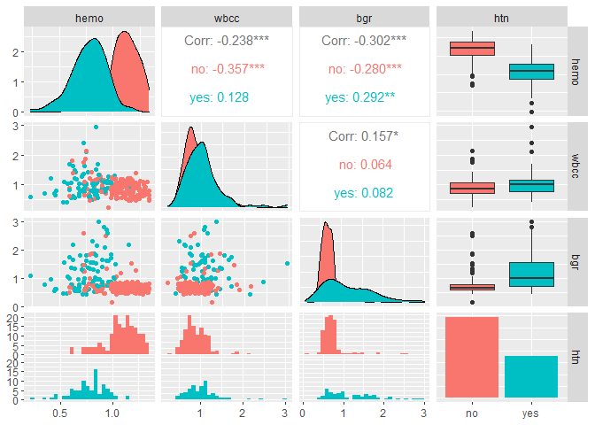

```r
options(repr.plot.width = 6, repr.plot.height = 5)
plotting <- new_scaled_hyper2 %>% ggpairs(aes(color = htn))
plotting
```

```r
set.seed(1234)
training_rows2 <- new_scaled_hyper2 %>%
  select(htn) %>%
  unlist() %>% # converts Class from a tibble to a vector
  createDataPartition(p = 0.75, list = FALSE)
```

```r
training_set2 <- new_scaled_hyper2  %>% slice(training_rows2)
testing_set2 <- new_scaled_hyper2  %>% slice(-training_rows2)
X_train2 <- training_set2 %>%
  select(-htn) %>%
  data.frame()
Y_train2 <- training_set2 %>%
  select(htn) %>%
  unlist()
```

```r
ks <- data.frame(k = seq(from = 1, to = 30, by = 2))
train_control <- trainControl(method = "cv", number = 10)
choose_k <- train(x = X_train2, y = Y_train2,  method = "knn", tuneGrid = ks, trControl = train_control)
```

```r
options(repr.plot.width = 4, repr.plot.height = 2.5)
k_accuracies <- choose_k$results
k_accuracies
```

```
##     k  Accuracy     Kappa AccuracySD   KappaSD
## 1   1 0.8573684 0.6794760 0.07946032 0.1758958
## 2   3 0.8468421 0.6571590 0.09940420 0.2067989
## 3   5 0.8623684 0.6945266 0.07620026 0.1623770
## 4   7 0.8576316 0.6775142 0.09071592 0.2036786
## 5   9 0.8576316 0.6796748 0.09947887 0.2264896
## 6  11 0.8423684 0.6521299 0.11802370 0.2533372
## 7  13 0.8478947 0.6568751 0.11034376 0.2452383
## 8  15 0.8428947 0.6402090 0.12093212 0.2778346
## 9  17 0.8428947 0.6396368 0.10626026 0.2460777
## 10 19 0.8376316 0.6264325 0.10469915 0.2424475
## 11 21 0.8376316 0.6217357 0.09864463 0.2297917
## 12 23 0.8426316 0.6255843 0.09490563 0.2351740
## 13 25 0.8221053 0.5761013 0.09456775 0.2302746
## 14 27 0.8271053 0.5862612 0.08852307 0.2155962
## 15 29 0.8271053 0.5862612 0.08852307 0.2155962
```

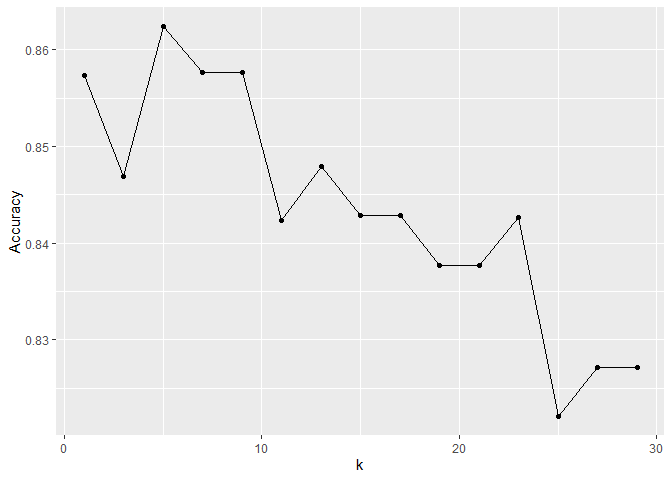

```r
choose_k_plot <- ggplot(k_accuracies, aes(x = k, y = Accuracy)) +
    geom_line() +
    geom_point()
choose_k_plot
```

```r
k = data.frame(k=11)
final_model <- train(x = X_train2, y = Y_train2, method = "knn", tuneGrid = k)

X_test2 <- testing_set2 %>%
    select(-htn) %>%
    data.frame()
Y_test2 <- testing_set2 %>%
    select(htn) %>%
    unlist()

test_pred <- predict(final_model, X_test2)
test_results <- confusionMatrix(table(test_pred, Y_test2))
test_results
```

```
## Confusion Matrix and Statistics
##
##          Y_test2
## test_pred no yes
##       no  37   9
##       yes  6  13
##
##                Accuracy : 0.7692
##                  95% CI : (0.6481, 0.8647)
##     No Information Rate : 0.6615
##     P-Value [Acc > NIR] : 0.04111
##
##                   Kappa : 0.4669
##
##  Mcnemar's Test P-Value : 0.60558
##
##             Sensitivity : 0.8605
##             Specificity : 0.5909
##          Pos Pred Value : 0.8043
##          Neg Pred Value : 0.6842
##              Prevalence : 0.6615
##          Detection Rate : 0.5692
##    Detection Prevalence : 0.7077
##       Balanced Accuracy : 0.7257
##
##        'Positive' Class : no
##
```

### Classifier 3

The third classifier built used the randomized variables Packed Cell Volume, Red Blood Cell Count and Potassium.

```r
dataset_hyper2 <- hypertension_data %>% select(pcv,rbcc,pot, htn)
new_dataset_hyper2 <- dataset_hyper2 %>%
    na.omit()
scaled_hyper2 <- new_dataset_hyper2 %>%
  select(-c(htn)) %>%
  scale(center = FALSE) %>% data.frame()
htn_column <- new_dataset_hyper2 %>%
        select(htn) %>% data.frame()
new_scaled_hyper2 <- cbind(scaled_hyper2, htn_column)
head(new_scaled_hyper2)
```

```
##         pcv      rbcc       pot htn
## 1 0.7770149 0.8039175 0.4625649 yes
## 2 0.9469869 0.9069838 0.5920830 yes
## 3 0.7041697 0.7626910 0.6845960 yes
## 4 0.7770149 0.7833042 0.7771089 yes
## 5 0.6798880 0.7008512 1.0731505 yes
## 6 0.3885074 0.5359450 1.1841660 yes
```

```r
nrow(new_scaled_hyper2)
```

```
## [1] 233
```

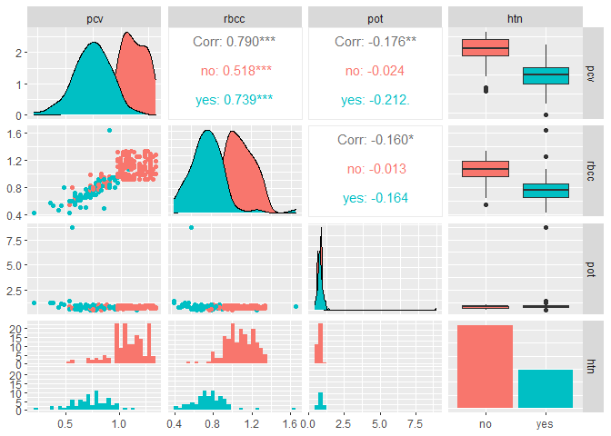

```r
options(repr.plot.width = 6, repr.plot.height = 5)
plotting <- new_scaled_hyper2 %>% ggpairs(aes(color = htn))
plotting
```

```r
set.seed(1234)
training_rows2 <- new_scaled_hyper2 %>%
  select(htn) %>%
  unlist() %>% # converts Class from a tibble to a vector
  createDataPartition(p = 0.75, list = FALSE)
```

```r
training_set2 <- new_scaled_hyper2  %>% slice(training_rows2)
testing_set2 <- new_scaled_hyper2  %>% slice(-training_rows2)
X_train2 <- training_set2 %>%
  select(-htn) %>%
  data.frame()
Y_train2 <- training_set2 %>%
  select(htn) %>%
  unlist()
```

```r
ks <- data.frame(k = seq(from = 1, to = 70, by = 5))
train_control <- trainControl(method = "cv", number = 10)
choose_k <- train(x = X_train2, y = Y_train2,  method = "knn", tuneGrid = ks, trControl = train_control)
```

```r
options(repr.plot.width = 4, repr.plot.height = 2.5)
k_accuracies <- choose_k$results
k_accuracies
```

```
##     k  Accuracy     Kappa AccuracySD   KappaSD
## 1   1 0.8346405 0.6015088 0.07982899 0.2043550
## 2   6 0.8856209 0.7469047 0.06739742 0.1387920
## 3  11 0.8970588 0.7746121 0.06055802 0.1214340
## 4  16 0.8859477 0.7486456 0.05519018 0.1066048
## 5  21 0.8859477 0.7438452 0.05519018 0.1175370
## 6  26 0.8803922 0.7297148 0.05760457 0.1249735
## 7  31 0.8862745 0.7430039 0.06074487 0.1303804
## 8  36 0.8918301 0.7549604 0.06348903 0.1364350
## 9  41 0.8807190 0.7287746 0.05727507 0.1225635
## 10 46 0.8807190 0.7251467 0.06297860 0.1411035
## 11 51 0.8748366 0.7081155 0.05934670 0.1345445
## 12 56 0.8803922 0.7213624 0.06393138 0.1445408
## 13 61 0.8578431 0.6556959 0.05603937 0.1377681
## 14 66 0.8522876 0.6414667 0.04878423 0.1193403
```

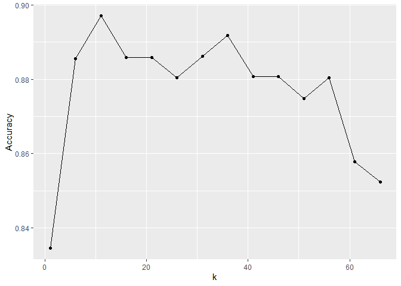

```r
choose_k_plot <- ggplot(k_accuracies, aes(x = k, y = Accuracy)) +
    geom_line() +
    geom_point()
choose_k_plot
```

```r
k = data.frame(k=16)
final_model <- train(x = X_train2, y = Y_train2, method = "knn", tuneGrid = k)

X_test2 <- testing_set2 %>%
    select(-htn) %>%
    data.frame()
Y_test2 <- testing_set2 %>%
    select(htn) %>%
    unlist()

test_pred <- predict(final_model, X_test2)
test_results <- confusionMatrix(table(test_pred, Y_test2))
test_results
```

```
## Confusion Matrix and Statistics
##
##          Y_test2
## test_pred no yes
##       no  33   2
##       yes  6  16
##
##                Accuracy : 0.8596
##                  95% CI : (0.7421, 0.9374)
##     No Information Rate : 0.6842
##     P-Value [Acc > NIR] : 0.002034
##
##                   Kappa : 0.6935
##
##  Mcnemar's Test P-Value : 0.288844
##
##             Sensitivity : 0.8462
##             Specificity : 0.8889
##          Pos Pred Value : 0.9429
##          Neg Pred Value : 0.7273
##              Prevalence : 0.6842
##          Detection Rate : 0.5789
##    Detection Prevalence : 0.6140
##       Balanced Accuracy : 0.8675
##
##        'Positive' Class : no
##
```

### Classifier 4

The fourth classifier took into account Serum Creatinine, White Blood Cell Count and Hemoglobin.

Retrieving and selecting data.

```r
dataset_hyper2 <- hypertension_data %>% select(sc,wbcc,hemo, htn)
new_dataset_hyper2 <- dataset_hyper2 %>%
    na.omit()
scaled_hyper2 <- new_dataset_hyper2 %>%
  select(-c(htn)) %>%
  scale(center = FALSE) %>% data.frame()
htn_column <- new_dataset_hyper2 %>%
        select(htn) %>% data.frame()
new_scaled_hyper2 <- cbind(scaled_hyper2, htn_column)
head(new_scaled_hyper2)
```

```
##          sc      wbcc      hemo htn
## 1 0.1964530 0.8738349 1.1669542 yes
## 2 0.1309687 0.6721807 0.8562716  no
## 3 0.2946795 0.8402259 0.7274520  no
## 4 0.6221012 0.7506018 0.8486940 yes
## 5 0.2291952 0.8178198 0.8790044  no
## 6 0.1800819 0.8738349 0.9244702 yes
```

```r
nrow(new_scaled_hyper2)
```

```
## [1] 278
```

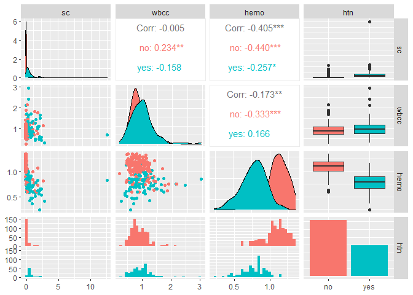

```r
options(repr.plot.width = 6, repr.plot.height = 5)
plotting <- new_scaled_hyper2 %>% ggpairs(aes(color = htn))
plotting
```

Creating data partition.

```r
set.seed(1234)
training_rows2 <- new_scaled_hyper2 %>%
  select(htn) %>%
  unlist() %>% # converts Class from a tibble to a vector
  createDataPartition(p = 0.75, list = FALSE)
```

Dividing dataset training set and testing set.

```r
training_set2 <- new_scaled_hyper2  %>% slice(training_rows2)
testing_set2 <- new_scaled_hyper2  %>% slice(-training_rows2)
X_train2 <- training_set2 %>%
  select(-htn) %>%
  data.frame()
Y_train2 <- training_set2 %>%
  select(htn) %>%
  unlist()
```

Selecting values a range of k values to train with and using cross-validation to reduce bias.

```r
ks <- data.frame(k = seq(from = 1, to = 70, by = 5))
train_control <- trainControl(method = "cv", number = 10)
choose_k <- train(x = X_train2, y = Y_train2,  method = "knn", tuneGrid = ks, trControl = train_control)
```

Retrieving the training model results and plotting k vs accuracy.

```r
options(repr.plot.width = 4, repr.plot.height = 2.5)
k_accuracies <- choose_k$results
k_accuracies
```

```
##     k  Accuracy     Kappa AccuracySD    KappaSD
## 1   1 0.7974892 0.5654218 0.07385336 0.16166278
## 2   6 0.8655844 0.7094144 0.05122076 0.11057772
## 3  11 0.8612771 0.7012732 0.04165009 0.09853654
## 4  16 0.8755844 0.7320114 0.04139903 0.09260532
## 5  21 0.8608225 0.6947729 0.04453641 0.10470498
## 6  26 0.8608225 0.6947729 0.04453641 0.10470498
## 7  31 0.8658225 0.7021165 0.04483237 0.10621922
## 8  36 0.8560606 0.6793722 0.04115376 0.09169443
## 9  41 0.8460823 0.6567186 0.05260096 0.11816252
## 10 46 0.8272294 0.6089409 0.06213129 0.14392212
## 11 51 0.8219913 0.5918411 0.06774244 0.15410101
## 12 56 0.8172294 0.5734798 0.07383517 0.17118643
## 13 61 0.8033983 0.5303152 0.07372064 0.18229497
## 14 66 0.7940909 0.5005428 0.07845079 0.20064617
```

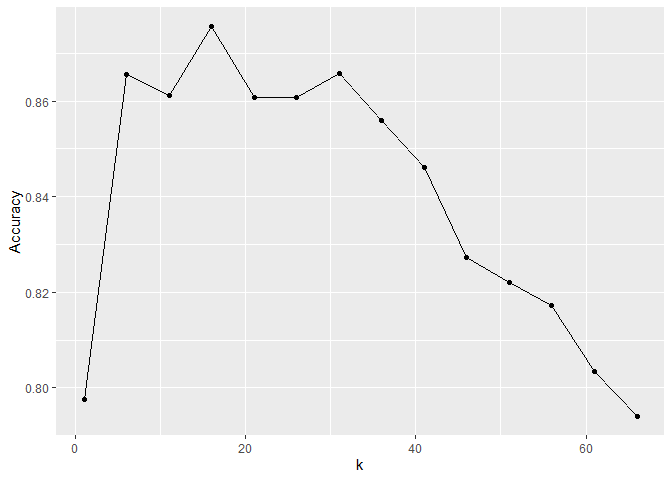

```r
choose_k_plot <- ggplot(k_accuracies, aes(x = k, y = Accuracy)) +
    geom_line() +
    geom_point()
choose_k_plot
```

```r
k = data.frame(k=16)
final_model <- train(x = X_train2, y = Y_train2, method = "knn", tuneGrid = k)

X_test2 <- testing_set2 %>%
    select(-htn) %>%
    data.frame()
Y_test2 <- testing_set2 %>%
    select(htn) %>%
    unlist()

test_pred <- predict(final_model, X_test2)
test_results <- confusionMatrix(table(test_pred, Y_test2))
test_results
```

```
## Confusion Matrix and Statistics
##
##          Y_test2
## test_pred no yes
##       no  38   5
##       yes  7  19
##
##                Accuracy : 0.8261
##                  95% CI : (0.7159, 0.9068)
##     No Information Rate : 0.6522
##     P-Value [Acc > NIR] : 0.001146
##
##                   Kappa : 0.624
##
##  Mcnemar's Test P-Value : 0.772830
##
##             Sensitivity : 0.8444
##             Specificity : 0.7917
##          Pos Pred Value : 0.8837
##          Neg Pred Value : 0.7308
##              Prevalence : 0.6522
##          Detection Rate : 0.5507
##    Detection Prevalence : 0.6232
##       Balanced Accuracy : 0.8181
##
##        'Positive' Class : no
##
```

## Discussion:

[output not shown]

Such findings could potentially cause other classification algorithms to be used for hypertension, as the result of a k-nn classification does not parallel that of existing research. This could potentially lead to questions about which algorithm would be optimal for this classification. Moreover, further analysis should be conducted on a hypertension specific dataset, to isolate whether the algorithm or the data is the cause of the differences.

Even though the results were different from what we had expected, we believe that if we had data tailored for Hypertension, we could establish the quality of the primary factors for more certainty.

## Bibliography

Hypertension : Hypertension, edited by Ragavendra R. Baliga, and George Bakris, Oxford University Press, Incorporated, 2012. ProQuest Ebook Central, https://ebookcentral.proquest.com/lib/ubc/detail.action?docID=1076092.

Risk Factors for High Blood Pressure (Hypertension). (n.d.). Retrieved from https://www.ucsfhealth.org/education/risk_factors_for_high_blood_pressure/

“High Salt Intake”. Yuan Ma, Feng J. He and Graham A. MacGregor. October 2015. https://www.ahajournals.org/doi/pdf/10.1161/HYPERTENSIONAHA.115.05948

Filipovsky, Jan, et al. “The Relationship of Blood Pressure with Glucose, Insulin, Heart Rate, Free Fatty Acids and Plasma Cortisol Levels According to Degree of Obesity in Middle-Aged Men.” Journal of Hypertension, vol. 14, no. 2, 1996, pp. 229-235.